# An Analysis of Crime in Los Angeles from 2010 to 2019

Author

Ellya Gholmieh

## Introduction

Crime has been a major issue in Los Angeles due to a variety of factors, including high population density, gang activity, and elevated levels of poverty and homelessness. As police officers respond to each incident, they are required to fill out a police report which is later transcribed to their digital record system. According to the Los Angeles Police Department Automated Report System (LAPD ARS), approximately 2.2 million crime incidents took place in Los Angeles from 2010 to 2019, although this figure may be an underestimate as many crimes go unreported. This paper aims to analyze the available data from LAPD ARS to identify which demographic experienced the most crime from 2010 to 2019, the types of crime they most reported, and the locations in Los Angeles where they occurred most frequently.

## Methods

Crime incident records were compiled from the LAPD ARS into the “Crime Data from 2010 to 2019” dataset, which was exported from the County of Los Angeles Open Data website. Exploratory analysis consisted of checking for duplicate records and looking at key variables, which included the victim’s age, gender, descent, crime code descriptions, and area markers (latitude, longitude, and geographic area names). No duplicate records were identified. Ages inputted as less than zero were replaced with ‘NA.’ Furthermore, upon analysis of crimes committed against victims of zero years of age, it was quickly realized that many of these crimes could not apply to a newborn infant. As zero may have been used to indicate an unknown age, ages of zero were replaced with ‘NA.’ With regards to the victim’s gender, identifications not consistent with male or female were replaced with ‘NA.’ The variety of options for victim’s descent was summarized into 5 categories: Asian, Black, Hispanic, White, and Pacific Islander. Unknown or missing descent data was replaced with ‘NA.’ No data was missing from crime code descriptions or area names. However, latitude and longitude values of “0” were replaced with ‘NA.’ Bar plots, histograms, and tables were used to examine the distribution of each variable.

Crime incidents with missing age, descent, gender, and area markers were removed from the dataset for further analysis. Data was grouped by descent and gender and visualized into a barplot to determine which demographic experienced the most crime incidents within Los Angeles. Furthermore, crime incidents were grouped by race and gender for each geographic area to see if there were differences between geographic areas. Next, data was grouped by descent, gender, and age to determine what age within these demographics experienced the most crime incidents. Age was categorized by year ranges of 10 and crime distributions according to age were analyzed for all crimes in Los Angeles and for crimes against the most targeted victim descent to determine if there was a difference. The top 5 crimes were evaluated for Los Angeles as a whole, for men, and for women. Lastly, the top 5 crimes were evaluated for the most targeted demographic in terms of gender and race, and then within the most targeted age range. The differences in the types of crime were then compared.

Lastly, the data of the demographic group was grouped by latitude and longitude to produce a map displaying the top 10 locations in Los Angeles where crime occurred. Next, we looked at the number of crime incidents in each geographic area for the targeted demographic and created a bar plot of the top 10 geographic areas (out of 21). All data analysis was done using RStudio.

## Results

When stratifying the crime incidents by race and gender, we can see that for most ethnic descents, women and men reported similar numbers of crime incidents for the 2010-2019 period. The largest difference in reported crimes was between Black women and men, in which Black women reported approximately 50,000 more crime incidents. Overall, however, Hispanics experienced the highest number of crime incidents, with Hispanic women experiencing slightly more than Hispanic men and the most of all demographics. After the Hispanic population, Whites experienced the most crime, followed by Black, Pacific Islander, and then Asian. We will now focus on Hispanic females.

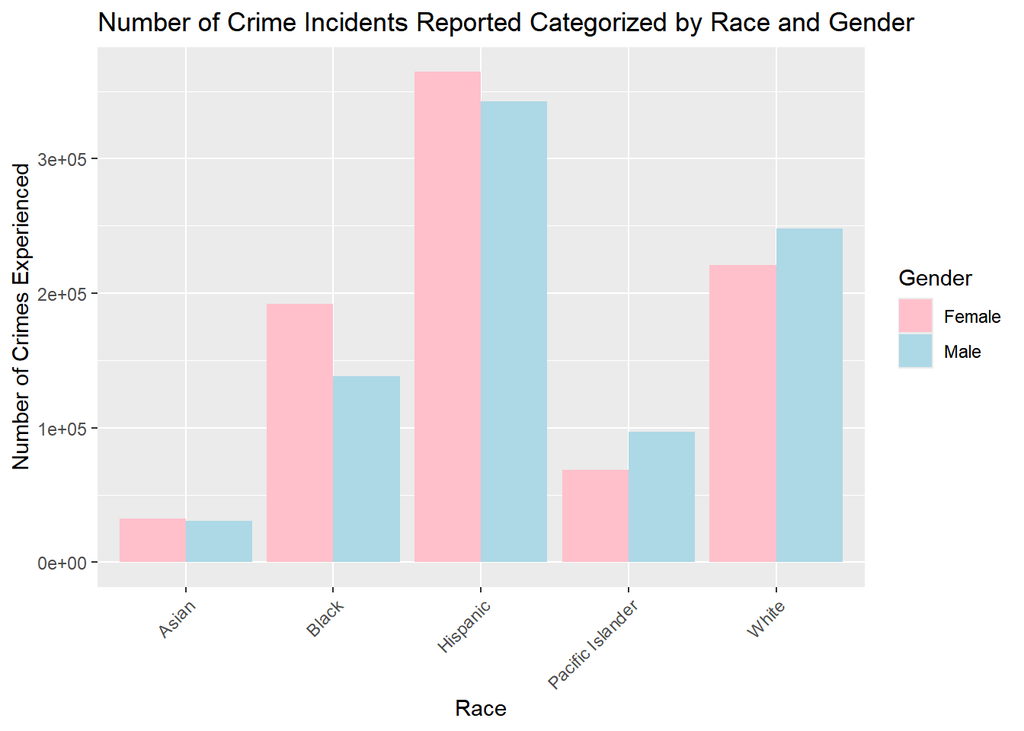

```r
LAdatanomissing |>
  ggplot() +
  geom_bar(mapping = aes(x = `Vict Descent`, fill = `Vict Sex`), position = "dodge") +
  labs(title = "Number of Crime Incidents Reported Categorized by Race and Gender") +
  labs(x = "Race", y = "Number of Crimes Experienced", fill = "Gender") +
  scale_fill_manual(values = c("F" = "pink", "M" = "lightblue"),
                    labels = c("F" = "Female", "M" = "Male")) +
  scale_x_discrete(labels = c(
    "A" = "Asian",
    "B" = "Black",
    "H" = "Hispanic",
    "P" = "Pacific Islander",
    "W" = "White"
  )) +
  theme(axis.text.x = element_text(angle = 45, hjust = 1))
```

When we stratify by race and gender for each of these different geographic areas, we can see that there are different distributions of criminal incident reports for each area. In nearly all areas, Hispanics are ranked first or second in reporting the most crimes. Furthermore, in a majority of geographic areas, female Hispanics report more crimes than male Hispanics.

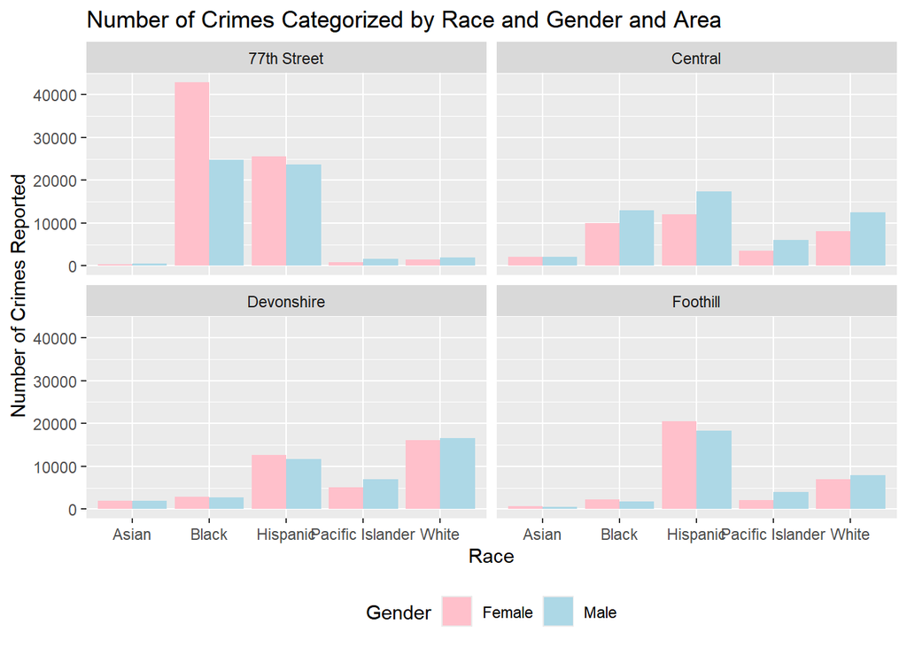

```r
LAdata1 <- LAdatanomissing[LAdatanomissing$`AREA NAME` %in% c("77th Street", "Central", "Devonshire", "Foothill")]
LAdata2 <- LAdatanomissing[LAdatanomissing$`AREA NAME` %in% c("Harbor", "Hollenbeck", "Hollywood", "Mission")]
LAdata3 <- LAdatanomissing[LAdatanomissing$`AREA NAME` %in% c("N Hollywood", "Newton", "Northeast", "Olympic")]
LAdata4 <- LAdatanomissing[LAdatanomissing$`AREA NAME` %in% c("Pacific", "Rampart", "Southeast", "Southwest")]
LAdata5 <- LAdatanomissing[LAdatanomissing$`AREA NAME` %in% c("Topanga", "Van Nuys", "West LA", "West Valley", "Wilshire")]


LAdata1[!is.na(`Vict Descent`) & !is.na(`Vict Sex`)] |>
  ggplot() +
  geom_bar(mapping = aes(x = `Vict Descent`, fill = `Vict Sex`), position = "dodge") +
  labs(title = "Number of Crimes Categorized by Race and Gender and Area") +
  labs(x = "Race", y = "Number of Crimes Reported", fill = "Gender") +
  scale_fill_manual(values = c("F" = "pink", "M" = "lightblue"),
                    labels = c("F" = "Female", "M" = "Male")) +
  scale_x_discrete(labels = c(
    "A" = "Asian",
    "B" = "Black",
    "H" = "Hispanic",
    "P" = "Pacific Islander",
    "W" = "White"
  )) +
  theme(legend.position = "bottom") +
  facet_wrap(~ `AREA NAME`, nrow = 2, ncol = 2)
```

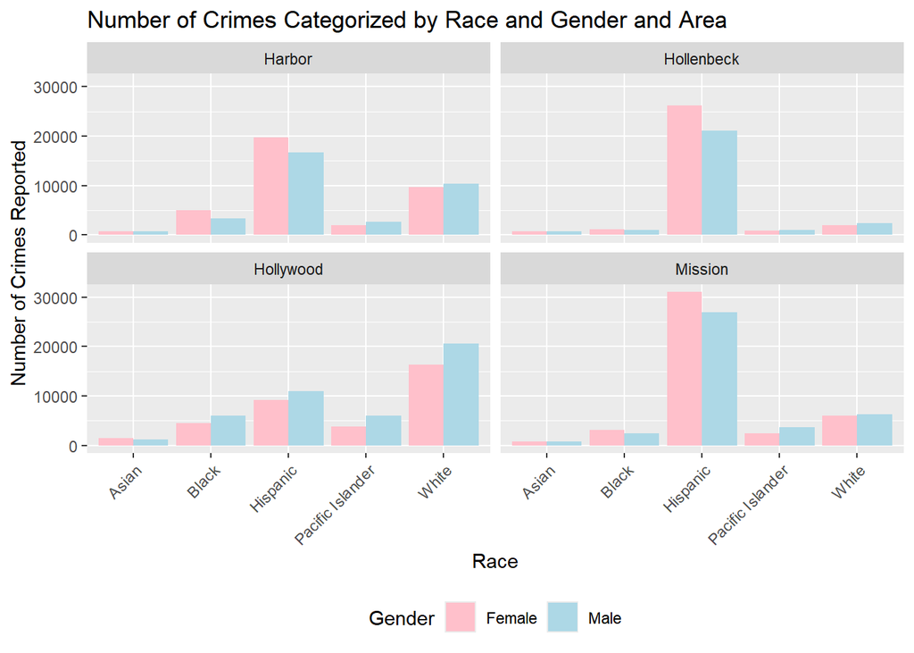

```r
LAdata2[!is.na(`Vict Descent`) & !is.na(`Vict Sex`)] |>
  ggplot() +
  geom_bar(mapping = aes(x = `Vict Descent`, fill = `Vict Sex`), position = "dodge") +
  labs(title = "Number of Crimes Categorized by Race and Gender and Area") +
  labs(x = "Race", y = "Number of Crimes Reported", fill = "Gender") +
  scale_fill_manual(values = c("F" = "pink", "M" = "lightblue"),
                    labels = c("F" = "Female", "M" = "Male")) +
  scale_x_discrete(labels = c(
    "A" = "Asian",
    "B" = "Black",
    "H" = "Hispanic",
    "P" = "Pacific Islander",
    "W" = "White"
  )) +
  theme(legend.position = "bottom") +
  theme(axis.text.x = element_text(angle = 45, hjust = 1)) +
  facet_wrap(~ `AREA NAME`, nrow = 2, ncol = 2)
```

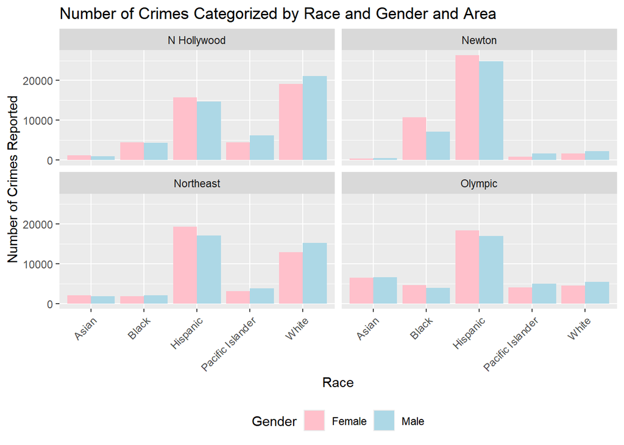

```r
LAdata3[!is.na(`Vict Descent`) & !is.na(`Vict Sex`)] |>
  ggplot() +
  geom_bar(mapping = aes(x = `Vict Descent`, fill = `Vict Sex`), position = "dodge") +
  labs(title = "Number of Crimes Categorized by Race and Gender and Area") +
  labs(x = "Race", y = "Number of Crimes Reported", fill = "Gender") +
  scale_fill_manual(values = c("F" = "pink", "M" = "lightblue"),
                    labels = c("F" = "Female", "M" = "Male")) +
  scale_x_discrete(labels = c(
    "A" = "Asian",
    "B" = "Black",
    "H" = "Hispanic",
    "P" = "Pacific Islander",
    "W" = "White"
  )) +
  theme(legend.position = "bottom") +
  theme(axis.text.x = element_text(angle = 45, hjust = 1)) +
  facet_wrap(~ `AREA NAME`, nrow = 2, ncol = 2)
```

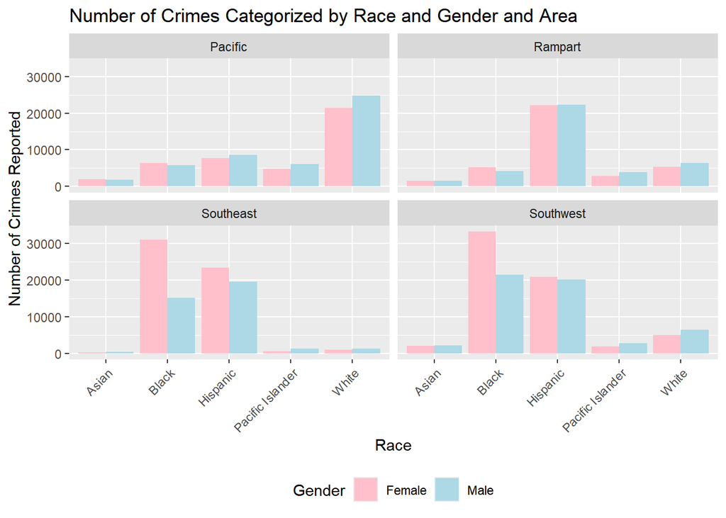

```r
LAdata4[!is.na(`Vict Descent`) & !is.na(`Vict Sex`)] |>
  ggplot() +
  geom_bar(mapping = aes(x = `Vict Descent`, fill = `Vict Sex`), position = "dodge") +
  labs(title = "Number of Crimes Categorized by Race and Gender and Area") +
  labs(x = "Race", y = "Number of Crimes Reported", fill = "Gender") +
  scale_fill_manual(values = c("F" = "pink", "M" = "lightblue"),
                    labels = c("F" = "Female", "M" = "Male")) +
  scale_x_discrete(labels = c(
    "A" = "Asian",
    "B" = "Black",
    "H" = "Hispanic",
    "P" = "Pacific Islander",
    "W" = "White"
  )) +
  theme(legend.position = "bottom") +
  theme(axis.text.x = element_text(angle = 45, hjust = 1)) +
  facet_wrap(~ `AREA NAME`, nrow = 2, ncol = 2)
```

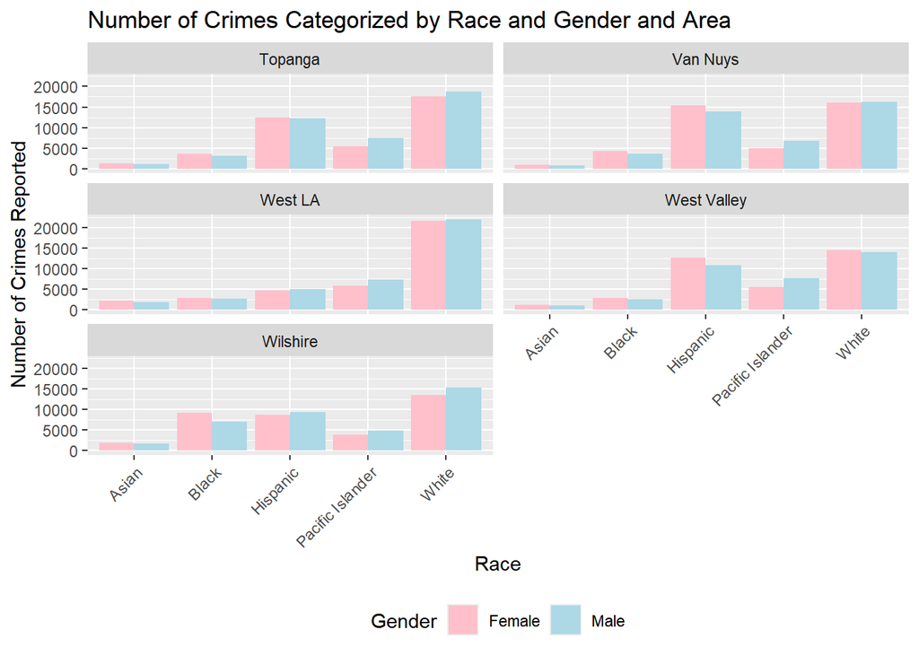

```r
LAdata5[!is.na(`Vict Descent`) & !is.na(`Vict Sex`)] |>
  ggplot() +
  geom_bar(mapping = aes(x = `Vict Descent`, fill = `Vict Sex`), position = "dodge") +
  labs(title = "Number of Crimes Categorized by Race and Gender and Area") +
  labs(x = "Race", y = "Number of Crimes Reported", fill = "Gender") +
  scale_fill_manual(values = c("F" = "pink", "M" = "lightblue"),
                    labels = c("F" = "Female", "M" = "Male")) +
  scale_x_discrete(labels = c(
    "A" = "Asian",
    "B" = "Black",
    "H" = "Hispanic",
    "P" = "Pacific Islander",
    "W" = "White"
  )) +
  theme(legend.position = "bottom") +
  theme(axis.text.x = element_text(angle = 45, hjust = 1)) +
  facet_wrap(~ `AREA NAME`, nrow = 3, ncol = 2)
```

Looking at the age distribution of Hispanic female victims who reported crimes, we can see that it was the 20-29 age category who reported the most crimes. They were then followed by 30-39 year olds and 40-49 year olds. However, the age distribution did not differ very much from that of Los Angeles as a whole. From these data, we understand that the demographic that reported the most crime incidents were female Hispanics aged 20-29 years old. More specifically, when grouping by age, ethnic descent, and gender, we can determine that most reports were made by Hispanic females aged 24 years old.

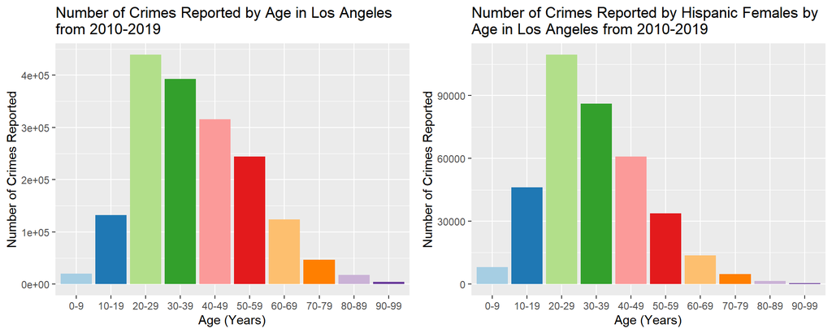

```r
library(gridExtra)
grid.arrange(plotLAage, plotHFage, ncol = 2)
```

When comparing the top 5 reported crimes for each category, we can see that battery, burglary from a vehicle, and petty theft are common for all categories. Compared to men, women report being assaulted by their intimate partner. On the other hand, more men report more violent crimes, such as assault with a deadly weapon/aggravated assault. When comparing the Hispanic females aged 20-29 to our general female category, we can see that the first and second most reported crimes are switched, with most Hispanic women reporting being assaulted by their intimate partner. They also report more vandalism incidents compared to identity theft.

**Table 1.** Top 5 crimes for the city of Los Angeles, for males in Los Angeles, for females in Los Angeles, and for Hispanic females aged 20-29 in Los Angeles from 2010-2019.

| Ranking of Reported Crimes | Top Crimes for Los Angeles | Top Crimes for Males | Top Crimes for Females | Top Crimes for Hispanic Females Aged 20-29 |
| --- | --- | --- | --- | --- |
| 1 | Battery - Simple Assault | Battery - Simple Assault | Battery - Simple Assault | Intimate Partner - Simple Assault |
| 2 | Burglary from Vehicle | Burglary from Vehicle | Intimate Partner - Simple Assault | Battery - Simple Assault |
| 3 | Petty Theft (< $950) | Burglary | Burglary from Vehicle | Burglary from Vehicle |
| 4 | Identity Theft | Assault with Deadly Weapon, Aggravated Assault | Petty Theft (< $950) | Petty Theft (< $950) |
| 5 | Burglary | Petty Theft (< $950) | Identity Theft | Vandalism - Felony (> $400) |

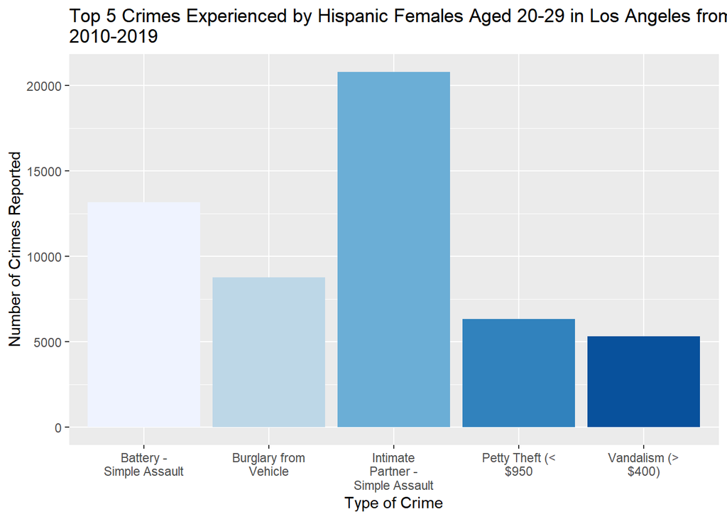

```r
#Top 5 Crimes reported by hispanic women between 20 and 29
HispanicFemalecrimesAge <- HispanicFemales |>
 filter(!is.na(`Crm Cd Desc`) &
        !is.na(`Vict Sex`) &
        !is.na(`Vict Descent`) &
        AgeGroup == "20-29") |>
  group_by(`Crm Cd Desc`) |>
  summarize(
    Entries = n(),
    .groups = 'drop') |>
  arrange(desc(Entries)) |>
  top_n(5, Entries)

custom_label <- c(
  "BATTERY - SIMPLE ASSAULT" = "Battery - Simple Assault",
  "BURGLARY FROM VEHICLE" = "Burglary from Vehicle",
  "INTIMATE PARTNER - SIMPLE ASSAULT" = "Intimate Partner - Simple Assault",
  "THEFT PLAIN - PETTY ($950 & UNDER)" = "Petty Theft (< $950",
  "VANDALISM - FELONY ($400 & OVER, ALL CHURCH VANDALISMS)" = "Vandalism (> $400)"
)

wrapped_labels <- sapply(custom_label, function(x) str_wrap(x, width = 15))

custom_title3 <- c("Top 5 Crimes Experienced by Hispanic Females Aged 20-29 in Los Angeles from 2010-2019")
wrapped_title3 <- sapply(custom_title3, function(x) str_wrap(x, width = 75))

ggplot(data = HispanicFemalecrimesAge, aes(x = `Crm Cd Desc`, y = Entries, fill = `Crm Cd Desc`)) +
  geom_bar(stat = "identity") +
  scale_fill_brewer(palette = "Blues", labels = custom_label) +
  labs(title = wrapped_title3) +
  labs(x = "Type of Crime", y = "Number of Crimes Reported") +
  scale_x_discrete(labels = wrapped_labels) +
  theme(legend.position = "none")
```

When mapping the top 10 locations where crimes against female Hispanics aged 20-29 occurred in Los Angeles from 2010 to 2019, we can see that more than 500 crime incidents took place in downtown Los Angeles. The cross streets of Tampa Avenue and Devonshire Street was also a location of high criminal activity. These 10 locations seem to spread throughout Los Angeles except for the southern parts of the city.

```r
library(leaflet)

HispanicFemalemap <- LAdatanomissing |>
 filter(`Vict Sex` == "F" &
        `Vict Descent` == "H" &
        `Vict Age` >= 20 & `Vict Age` <= 29) |>
  group_by(`LAT`, `LON`) |>
  summarize(
    Entries = n(),
    .groups = 'drop') |>
  top_n(10, Entries) |>
  arrange(desc(Entries))

map.pal <- colorNumeric(c('green', 'yellow', 'red'), domain= HispanicFemalemap$Entries)
map.pal
```

[output not shown]

```r
locationmap <- leaflet(HispanicFemalemap) |>
  addProviderTiles('CartoDB.Positron') |>
  addCircles(
    lat = ~LAT, lng = ~LON,
    opacity = 0.5, fillOpacity = 0.5, radius = ~Entries * 3,
    color = map.pal(HispanicFemalemap$Entries)
  ) |>
  addLegend("bottomright", pal = map.pal, values = HispanicFemalemap$Entries, title = "Number of Crimes", opacity = 1) |>
  addControl("Top 10 Locations of Reported Crimes by Hispanic Females Aged 20-29 from 2010-2019", position = "topright")

locationmap
```

[interactive chart not shown]

Of the 21 geographic locations that make up Los Angeles, the top 10 areas that had the most crime incident reports from Hispanic women aged 20-29 in order from most to least are: Mission, Newton, 77th Street, Southeast, Hollenbeck, Southwest, Rampart, Foothill, Olympic, and Harbor.

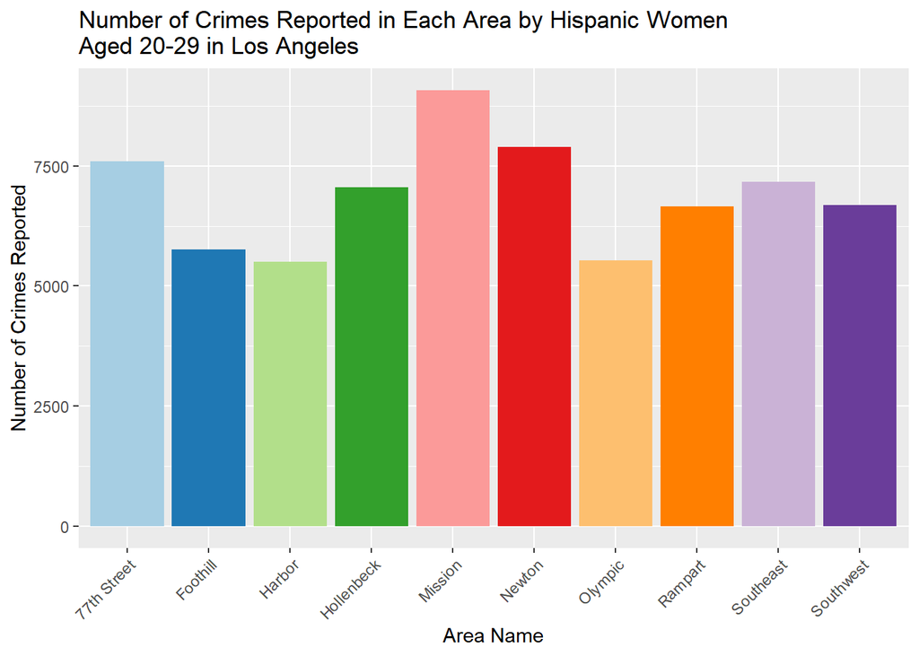

```r
custom_title4 <- c("Number of Crimes Reported in Each Area by Hispanic Women Aged 20-29 in Los Angeles")
wrapped_title4 <- sapply(custom_title4, function(x) str_wrap(x, width = 60))

HispanicFemalearea |>
  ggplot(aes(x = `AREA NAME`, y = Entries, fill = `AREA NAME`)) +
  geom_bar(stat = "identity") +
  labs(title = wrapped_title4) +
  labs(x = "Area Name", y = "Number of Crimes Reported") +
  scale_fill_brewer(palette = "Paired") +
  theme(axis.text.x = element_text(angle = 45, hjust = 1)) +
  theme(legend.position = "none")
```

## Discussion

According to the data analysis, the demographic that has been the victim of the most crimes in Los Angeles from 2010-2019 are Hispanic females aged 20-29 (or more specifically, those aged 24). This follows the same age distribution of the city and is therefore not unexpected. The number one crime they report is “Intimate Partner - Simple Assault”, whereas for females in general, this is the second most reported crime. This may be due to the Latin culture’s tradition of “El Machismo” in which Latino men want to be seen as extremely masculine, leading to aggressive and/or abusive behavior towards their intimate partners to foster an environment of obedience[^1]. However, the number of reports towards intimate partner abuse is much higher than the other reported crimes, showing that it was the most prominent issue for young Hispanic women. More current data is needed to determine if this is still the most reported crime they face in Los Angeles and research should be aimed at dismantling the tradition of “El Machismo” and promoting the safety of Hispanic women within their relationships.

## Footnotes

[^1]: Ycastmediagroup. (2024, June 12). *Hispanic tradition of “El machismo” can lead to abuse*. YMG. https://www.youthcastmediagroup.org/post/hispanic-tradition-of-el-machismo-can-lead-to-abuse